# Cyclistic Casestudy

Naveed Narejo

2023-02-21

# Google Data Analytics Capstone: Cyclistic Case Study

Cyclistic case study is the a part of of Google’s Data Analytics Professional Certificate program. in this case study analyst have to analyze that how Does a Bike-Share Navigate Speedy Success? The analyst must follow following steps of the data analysis process (Ask, Prepare, Process, Analyze, Share, and Act).

## Step 1: Ask

### About the Company :

Cyclistic is a bike-share company based in Chicago with two types of customers. Customers who purchase single-ride or full-day passes are known as casual riders, while those who purchase annual memberships are known as members. Cyclistic’s financial analysts have concluded that annual members are much more profitable than casual riders. The director of marketing believes the company’s future success depends on maximizing the number of annual memberships.

The marketing analytics team wants to understand how casual riders and annual members use Cyclistic bikes differently. From these insights, the team will design a new marketing strategy to convert casual riders into annual members.

##### Key Stakeholders:

- Lily Moreno: The director of marketing. Moreno is responsible for the development of campaigns and initiatives to promote the bike-share program.
- Cyclistic marketing analytics team: A team of data analysts who are responsible for collecting, analysing, and reporting data that helps guide Cyclistic marketing strategy.
- Cyclistic executive team: The executive team will decide whether to approve the recommended marketing program.

###### Business Task :

Design marketing strategies aimed at converting casual riders into annual members consider following cases. 1) How do annual members and casual riders use Cyclistic bikes differently? 2) Why would casual riders buy Cyclistic annual memberships? 3) How annual members and casual riders use Cyclistic bikes differently.?

### Deliverables:

- A description of all data sources used
- Documentation of any cleaning or manipulation of data
- A summary of the analysis
- Supporting visualisations and key findings
- Top three to four recommendations based on the analysis

## Step 2: Prepare

###### Data sources:

We’ll be using Cyclistic’s historical bike trip data from the last 12 months, which is publicly available here. The data is made available by Motivate International Inc. under this license [license](https://ride.divvybikes.com/data-license-agreement). The data is stored in spreadsheets. There are 12 .CSV files total for year 2022. [Click here for Data.](https://divvy-tripdata.s3.amazonaws.com/index.html)

The data set contains 12 .CSV files organized in long format. Below is a breakdown of the data using the ROCCC approach: - - Reliable and original: this is public data that contains accurate, complete and unbiased info on Cyclistic’s historical bike trips. It can be used to explore how different customer types are using Cyclistic bikes.

- Comprehensive and current: these sources contain all the data needed to understand the different ways members and casual riders use Cyclistic bikes. The data is from the past 12 months. It is current and relevant to the task at hand. This is important because the usefulness of data decreases as time passes.
- Cited:these sources are publicly available data provided by Cyclistic and the City of Chicago. Governmental agency data and vetted public data are typically good sources of data.

### Installing R-Package

Installing the R-packages needed for the required analysis.

```r
  # install.packages("tidyverse")   #   Functions: dplyr(), tidyr() , stringr(), tibble(), readr(), purrr(), ggplot2() )
  # install.packages("janitor")     #   Functions: clean_names(), remove_empty(), get_dupes() )
  # install.packages("lubridate")   #   Functions: datetime fuctions
  # install.packages("dplyr")       #   Functions: pipes()
  # install.packages("ggplot2")      #
```

## Loading R Environment

Loading the packages needed for the data processing and required analysis.

```r
#Loading the packages needed for the data processing and required analysis.

library(tidyverse)  #helps wrangle data
library(lubridate)  #helps wrangle date attributes
```

```r
library(ggplot2)  #helps visualize data
library(janitor)    #   Functions: clean_names(), remove_empty(), get_dupes() )
```

## Step 3: Process

### Importing files

For this analysis we will be using these 12 .CSVs. (jan2022, feb2022, mar2022,apr2022, may2022, jun2022,jul2022, aug2022,sep2022,oct2022,nov2022,dec2022)

```r
jan2022 <- read_csv(file = "D:\\Bicycle Casestudy\\Data\\202201-divvy-tripdata.csv") %>%
  remove_empty()
```

```
## value for "which" not specified, defaulting to c("rows", "cols")
```

```r
  head(jan2022)
```

```
## # A tibble: 6 × 13
##   ride_id        ridea…¹ started_at          ended_at            start…² start…³
##   <chr>          <chr>   <dttm>              <dttm>              <chr>   <chr>
## 1 C2F7DD78E82EC… electr… 2022-01-13 11:59:47 2022-01-13 12:02:44 Glenwo… 525
## 2 A6CF8980A652D… electr… 2022-01-10 08:41:56 2022-01-10 08:46:17 Glenwo… 525
## 3 BD0F91DFF741C… classi… 2022-01-25 04:53:40 2022-01-25 04:58:01 Sheffi… TA1306…
## 4 CBB80ED419105… classi… 2022-01-04 00:18:04 2022-01-04 00:33:00 Clark … KA1504…
## 5 DDC963BFDDA51… classi… 2022-01-20 01:31:10 2022-01-20 01:37:12 Michig… TA1309…
## 6 A39C6F6CC0586… classi… 2022-01-11 18:48:09 2022-01-11 18:51:31 Wood S… 637
## # … with 7 more variables: end_station_name <chr>, end_station_id <chr>,
## #   start_lat <dbl>, start_lng <dbl>, end_lat <dbl>, end_lng <dbl>,
## #   member_casual <chr>, and abbreviated variable names ¹rideable_type,
## #   ²start_station_name, ³start_station_id
```

```r
feb2022 <- read_csv(file = "D:\\Bicycle Casestudy\\Data\\202202-divvy-tripdata.csv") %>%
  remove_empty()
```

```
## value for "which" not specified, defaulting to c("rows", "cols")
```

```r
  head(feb2022)
```

```
## # A tibble: 6 × 13
##   ride_id        ridea…¹ started_at          ended_at            start…² start…³
##   <chr>          <chr>   <dttm>              <dttm>              <chr>   <chr>
## 1 E1E065E7ED285… classi… 2022-02-19 18:08:41 2022-02-19 18:23:56 State … TA1305…
## 2 1602DCDC5B30F… classi… 2022-02-20 17:41:30 2022-02-20 17:45:56 Halste… TA1309…
## 3 BE7DD2AF4B55C… classi… 2022-02-25 18:55:56 2022-02-25 19:09:34 State … TA1305…
## 4 A1789BDF84441… classi… 2022-02-14 11:57:03 2022-02-14 12:04:00 Southp… 13235
## 5 07DE78092C62F… classi… 2022-02-16 05:36:06 2022-02-16 05:39:00 State … TA1305…
## 6 9A2F204F04AB7… classi… 2022-02-07 09:51:57 2022-02-07 10:07:53 St. Cl… 13016
## # … with 7 more variables: end_station_name <chr>, end_station_id <chr>,
## #   start_lat <dbl>, start_lng <dbl>, end_lat <dbl>, end_lng <dbl>,
## #   member_casual <chr>, and abbreviated variable names ¹rideable_type,
## #   ²start_station_name, ³start_station_id
```

```r
mar2022<- read_csv(file = "D:\\Bicycle Casestudy\\Data\\202203-divvy-tripdata.csv") %>%
  remove_empty()
```

```
## value for "which" not specified, defaulting to c("rows", "cols")
```

```r
  head(mar2022)
```

```
## # A tibble: 6 × 13
##   ride_id        ridea…¹ started_at          ended_at            start…² start…³
##   <chr>          <chr>   <dttm>              <dttm>              <chr>   <chr>
## 1 47EC0A7F82E65… classi… 2022-03-21 13:45:01 2022-03-21 13:51:18 Wabash… TA1307…
## 2 8494861979B0F… electr… 2022-03-16 09:37:16 2022-03-16 09:43:34 Michig… 13042
## 3 EFE527AF80B66… classi… 2022-03-23 19:52:02 2022-03-23 19:54:48 Broadw… 13109
## 4 9F446FD9DEE3F… classi… 2022-03-01 19:12:26 2022-03-01 19:22:14 Wabash… TA1307…
## 5 431128AD9AFFE… classi… 2022-03-21 18:37:01 2022-03-21 19:19:11 DuSabl… LF-005
## 6 9AA8A13AF7A85… classi… 2022-03-07 17:10:22 2022-03-07 17:15:04 Bissel… 13059
## # … with 7 more variables: end_station_name <chr>, end_station_id <chr>,
## #   start_lat <dbl>, start_lng <dbl>, end_lat <dbl>, end_lng <dbl>,
## #   member_casual <chr>, and abbreviated variable names ¹rideable_type,
## #   ²start_station_name, ³start_station_id
```

```r
apr2022<- read_csv(file = "D:\\Bicycle Casestudy\\Data\\202204-divvy-tripdata.csv") %>%
  remove_empty()
```

```
## value for "which" not specified, defaulting to c("rows", "cols")
```

```r
  head(apr2022)
```

```
## # A tibble: 6 × 13
##   ride_id        ridea…¹ started_at          ended_at            start…² start…³
##   <chr>          <chr>   <dttm>              <dttm>              <chr>   <chr>
## 1 3564070EEFD12… electr… 2022-04-06 17:42:48 2022-04-06 17:54:36 Paulin… 515
## 2 0B820C7FCF22F… classi… 2022-04-24 19:23:07 2022-04-24 19:43:17 Wentwo… 13075
## 3 89EEEE32293F0… classi… 2022-04-20 19:29:08 2022-04-20 19:35:16 Halste… TA1307…
## 4 84D4751AEB318… classi… 2022-04-22 21:14:06 2022-04-22 21:23:29 Wentwo… 13075
## 5 5664BCF0D1DE7… electr… 2022-04-16 15:56:30 2022-04-16 16:02:11 Halste… TA1307…
## 6 AA9EB7BD2E1FC… classi… 2022-04-21 16:52:33 2022-04-21 16:56:51 Despla… 15535
## # … with 7 more variables: end_station_name <chr>, end_station_id <chr>,
## #   start_lat <dbl>, start_lng <dbl>, end_lat <dbl>, end_lng <dbl>,
## #   member_casual <chr>, and abbreviated variable names ¹rideable_type,
## #   ²start_station_name, ³start_station_id
```

```r
may2022<- read_csv(file = "D:\\Bicycle Casestudy\\Data\\202205-divvy-tripdata.csv") %>%
  remove_empty()
```

```
## value for "which" not specified, defaulting to c("rows", "cols")
```

```r
  head(may2022)
```

```
## # A tibble: 6 × 13
##   ride_id        ridea…¹ started_at          ended_at            start…² start…³
##   <chr>          <chr>   <dttm>              <dttm>              <chr>   <chr>
## 1 EC2DE40644C6B… classi… 2022-05-23 23:06:58 2022-05-23 23:40:19 Wabash… TA1307…
## 2 1C31AD03897EE… classi… 2022-05-11 08:53:28 2022-05-11 09:31:22 DuSabl… 13300
## 3 1542FBEC83041… classi… 2022-05-26 18:36:28 2022-05-26 18:58:18 Clinto… TA1305…
## 4 6FF5985292452… classi… 2022-05-10 07:30:07 2022-05-10 07:38:49 Clinto… TA1305…
## 5 483C52CAAE12E… classi… 2022-05-10 17:31:56 2022-05-10 17:36:57 Clinto… TA1305…
## 6 C0A3AA5A614DC… classi… 2022-05-04 14:48:55 2022-05-04 14:56:04 Carpen… 13196
## # … with 7 more variables: end_station_name <chr>, end_station_id <chr>,
## #   start_lat <dbl>, start_lng <dbl>, end_lat <dbl>, end_lng <dbl>,
## #   member_casual <chr>, and abbreviated variable names ¹rideable_type,
## #   ²start_station_name, ³start_station_id
```

```r
jun2022 <- read_csv(file = "D:\\Bicycle Casestudy\\Data\\202206-divvy-tripdata.csv") %>%
  remove_empty()
```

```
## value for "which" not specified, defaulting to c("rows", "cols")
```

```r
  head(jun2022)
```

```
## # A tibble: 6 × 13
##   ride_id        ridea…¹ started_at          ended_at            start…² start…³
##   <chr>          <chr>   <dttm>              <dttm>              <chr>   <chr>
## 1 600CFD130D0FD… electr… 2022-06-30 17:27:53 2022-06-30 17:35:15 <NA>    <NA>
## 2 F5E6B5C1682C6… electr… 2022-06-30 18:39:52 2022-06-30 18:47:28 <NA>    <NA>
## 3 B6EB6D27BAD77… electr… 2022-06-30 11:49:25 2022-06-30 12:02:54 <NA>    <NA>
## 4 C9C320375DE1D… electr… 2022-06-30 11:15:25 2022-06-30 11:19:43 <NA>    <NA>
## 5 56C055851023B… electr… 2022-06-29 23:36:50 2022-06-29 23:45:17 <NA>    <NA>
## 6 B664188E8163D… electr… 2022-06-30 16:42:10 2022-06-30 16:58:22 <NA>    <NA>
## # … with 7 more variables: end_station_name <chr>, end_station_id <chr>,
## #   start_lat <dbl>, start_lng <dbl>, end_lat <dbl>, end_lng <dbl>,
## #   member_casual <chr>, and abbreviated variable names ¹rideable_type,
## #   ²start_station_name, ³start_station_id
```

```r
jul2022<- read_csv(file = "D:\\Bicycle Casestudy\\Data\\202207-divvy-tripdata.csv") %>%
  remove_empty()
```

```
## value for "which" not specified, defaulting to c("rows", "cols")
```

```r
  head(jul2022)
```

```
## # A tibble: 6 × 13
##   ride_id        ridea…¹ started_at          ended_at            start…² start…³
##   <chr>          <chr>   <dttm>              <dttm>              <chr>   <chr>
## 1 954144C2F67B1… classi… 2022-07-05 08:12:47 2022-07-05 08:24:32 Ashlan… 13224
## 2 292E027607D21… classi… 2022-07-26 12:53:38 2022-07-26 12:55:31 Buckin… 15541
## 3 57765852588AD… classi… 2022-07-03 13:58:49 2022-07-03 14:06:32 Buckin… 15541
## 4 B5B6BE4431459… classi… 2022-07-31 17:44:21 2022-07-31 18:42:50 Buckin… 15541
## 5 A4C331F2A00E7… classi… 2022-07-13 19:49:06 2022-07-13 20:15:24 Wabash… TA1307…
## 6 579D73BE2ED88… electr… 2022-07-01 17:04:35 2022-07-01 17:13:18 Despla… 15535
## # … with 7 more variables: end_station_name <chr>, end_station_id <chr>,
## #   start_lat <dbl>, start_lng <dbl>, end_lat <dbl>, end_lng <dbl>,
## #   member_casual <chr>, and abbreviated variable names ¹rideable_type,
## #   ²start_station_name, ³start_station_id
```

```r
aug2022<- read_csv(file = "D:\\Bicycle Casestudy\\Data\\202208-divvy-tripdata.csv") %>%
  remove_empty()
```

```
## value for "which" not specified, defaulting to c("rows", "cols")
```

```r
  head(aug2022)
```

```
## # A tibble: 6 × 13
##   ride_id        ridea…¹ started_at          ended_at            start…² start…³
##   <chr>          <chr>   <dttm>              <dttm>              <chr>   <chr>
## 1 550CF7EFEAE0C… electr… 2022-08-07 21:34:15 2022-08-07 21:41:46 <NA>    <NA>
## 2 DAD198F405F9C… electr… 2022-08-08 14:39:21 2022-08-08 14:53:23 <NA>    <NA>
## 3 E6F2BC47B65CB… electr… 2022-08-08 15:29:50 2022-08-08 15:40:34 <NA>    <NA>
## 4 F597830181C2E… electr… 2022-08-08 02:43:50 2022-08-08 02:58:53 <NA>    <NA>
## 5 0CE689BB4E313… electr… 2022-08-07 20:24:06 2022-08-07 20:29:58 <NA>    <NA>
## 6 BFA7E7CC69860… electr… 2022-08-08 13:06:08 2022-08-08 13:19:09 <NA>    <NA>
## # … with 7 more variables: end_station_name <chr>, end_station_id <chr>,
## #   start_lat <dbl>, start_lng <dbl>, end_lat <dbl>, end_lng <dbl>,
## #   member_casual <chr>, and abbreviated variable names ¹rideable_type,
## #   ²start_station_name, ³start_station_id
```

```r
sep2022<- read_csv(file = "D:\\Bicycle Casestudy\\Data\\202209-divvy-tripdata.csv") %>%
  remove_empty()
```

```
## value for "which" not specified, defaulting to c("rows", "cols")
```

```r
  head(sep2022)
```

```
## # A tibble: 6 × 13
##   ride_id        ridea…¹ started_at          ended_at            start…² start…³
##   <chr>          <chr>   <dttm>              <dttm>              <chr>   <chr>
## 1 5156990AC19CA… electr… 2022-09-01 08:36:22 2022-09-01 08:39:05 <NA>    <NA>
## 2 E12D4A16BF51C… electr… 2022-09-01 17:11:29 2022-09-01 17:14:45 <NA>    <NA>
## 3 A02B53CD7DB72… electr… 2022-09-01 17:15:50 2022-09-01 17:16:12 <NA>    <NA>
## 4 C82E05FEE872D… electr… 2022-09-01 09:00:28 2022-09-01 09:10:32 <NA>    <NA>
## 5 4DEEB4550A266… electr… 2022-09-01 07:30:11 2022-09-01 07:32:36 <NA>    <NA>
## 6 B1721F8C7C3AC… electr… 2022-09-01 12:04:25 2022-09-01 12:21:08 <NA>    <NA>
## # … with 7 more variables: end_station_name <chr>, end_station_id <chr>,
## #   start_lat <dbl>, start_lng <dbl>, end_lat <dbl>, end_lng <dbl>,
## #   member_casual <chr>, and abbreviated variable names ¹rideable_type,
## #   ²start_station_name, ³start_station_id
```

```r
oct2022<- read_csv(file = "D:\\Bicycle Casestudy\\Data\\202210-divvy-tripdata.csv") %>%
  remove_empty()
```

```
## value for "which" not specified, defaulting to c("rows", "cols")
```

```r
  head(oct2022)
```

```
## # A tibble: 6 × 13
##   ride_id        ridea…¹ started_at          ended_at            start…² start…³
##   <chr>          <chr>   <dttm>              <dttm>              <chr>   <chr>
## 1 A50255C1E1794… classi… 2022-10-14 17:13:30 2022-10-14 17:19:39 Noble … 13290
## 2 DB692A70BD2DD… electr… 2022-10-01 16:29:26 2022-10-01 16:49:06 Damen … 13288
## 3 3C02727AAF60F… electr… 2022-10-19 18:55:40 2022-10-19 19:03:30 Hoyne … 655
## 4 47E653FDC2D99… electr… 2022-10-31 07:52:36 2022-10-31 07:58:49 Rush S… KA1504…
## 5 8B5407BE53515… classi… 2022-10-13 18:41:03 2022-10-13 19:26:18 900 W … 13028
## 6 A177C92E9F021… electr… 2022-10-13 15:53:27 2022-10-13 15:59:17 900 W … 13028
## # … with 7 more variables: end_station_name <chr>, end_station_id <chr>,
## #   start_lat <dbl>, start_lng <dbl>, end_lat <dbl>, end_lng <dbl>,
## #   member_casual <chr>, and abbreviated variable names ¹rideable_type,
## #   ²start_station_name, ³start_station_id
```

```r
nov2022<- read_csv(file = "D:\\Bicycle Casestudy\\Data\\202211-divvy-tripdata.csv") %>%
  remove_empty()
```

```
## value for "which" not specified, defaulting to c("rows", "cols")
```

```r
  head(nov2022)
```

```
## # A tibble: 6 × 13
##   ride_id        ridea…¹ started_at          ended_at            start…² start…³
##   <chr>          <chr>   <dttm>              <dttm>              <chr>   <chr>
## 1 BCC66FC6FAB27… electr… 2022-11-10 06:21:55 2022-11-10 06:31:27 Canal … 13011
## 2 772AB67E902C1… classi… 2022-11-04 07:31:55 2022-11-04 07:46:25 Canal … 13011
## 3 585EAD07FDEC0… classi… 2022-11-21 17:20:29 2022-11-21 17:34:36 Indian… SL-005
## 4 91C4E7ED3C262… classi… 2022-11-25 17:29:34 2022-11-25 17:45:15 Indian… SL-005
## 5 709206A3104CA… classi… 2022-11-29 17:24:25 2022-11-29 17:42:51 Indian… SL-005
## 6 11DE62E16D1A6… classi… 2022-11-04 14:40:47 2022-11-04 14:52:35 Street… 13022
## # … with 7 more variables: end_station_name <chr>, end_station_id <chr>,
## #   start_lat <dbl>, start_lng <dbl>, end_lat <dbl>, end_lng <dbl>,
## #   member_casual <chr>, and abbreviated variable names ¹rideable_type,
## #   ²start_station_name, ³start_station_id
```

```r
dec2022<- read_csv(file = "D:\\Bicycle Casestudy\\Data\\202212-divvy-tripdata.csv") %>%
  remove_empty()
```

```
## value for "which" not specified, defaulting to c("rows", "cols")
```

```r
  head(dec2022)
```

```
## # A tibble: 6 × 13
##   ride_id        ridea…¹ started_at          ended_at            start…² start…³
##   <chr>          <chr>   <dttm>              <dttm>              <chr>   <chr>
## 1 65DBD2F447EC5… electr… 2022-12-05 10:47:18 2022-12-05 10:56:34 Clifto… TA1307…
## 2 0C201AA7EA0EA… classi… 2022-12-18 06:42:33 2022-12-18 07:08:44 Broadw… 13277
## 3 E0B148CCB358A… electr… 2022-12-13 08:47:45 2022-12-13 08:59:51 Sangam… TA1306…
## 4 54C5775D2B7C9… classi… 2022-12-13 18:50:47 2022-12-13 19:19:48 Shield… KA1503…
## 5 A4891F78776D3… classi… 2022-12-14 16:13:39 2022-12-14 16:27:50 Ashlan… 13247
## 6 DB91D9B8DFACA… electr… 2022-12-02 15:24:47 2022-12-02 15:34:14 Wabash… TA1309…
## # … with 7 more variables: end_station_name <chr>, end_station_id <chr>,
## #   start_lat <dbl>, start_lng <dbl>, end_lat <dbl>, end_lng <dbl>,
## #   member_casual <chr>, and abbreviated variable names ¹rideable_type,
## #   ²start_station_name, ³start_station_id
```

To make sure that everything required is imported correctly, we need to verify by using head() functions. Now that I’ve imported all of the data frames that I’ll be using, I can start cleaning up the data. I will look at each data frame to familiarize myself with the data and check for errors.I’ll be analyzing each file separately.

```r
 jan2022 <- clean_names(jan2022) # cleaning column names to snake format
 feb2022 <- clean_names(feb2022)
 mar2022 <- clean_names(mar2022)
 apr2022 <- clean_names(apr2022)
 may2022 <- clean_names(may2022)
 jun2022 <- clean_names(jun2022)
 jul2022 <- clean_names(jul2022)
 aug2022 <- clean_names(aug2022)
 sep2022 <- clean_names(sep2022)
 oct2022 <- clean_names(oct2022)
 nov2022 <- clean_names(nov2022)
 dec2022 <- clean_names(dec2022)
```

In the above chunks i’ve cleaned the all dataframe column names to snake format

```r
 get_dupes(jan2022) # checking for duplicates
```

```
## No variable names specified - using all columns.
```

```
## No duplicate combinations found of: ride_id, rideable_type, started_at, ended_at, start_station_name, start_station_id, end_station_name, end_station_id, start_lat, ... and 4 other variables
```

```
## # A tibble: 0 × 14
## # … with 14 variables: ride_id <chr>, rideable_type <chr>, started_at <dttm>,
## #   ended_at <dttm>, start_station_name <chr>, start_station_id <chr>,
## #   end_station_name <chr>, end_station_id <chr>, start_lat <dbl>,
## #   start_lng <dbl>, end_lat <dbl>, end_lng <dbl>, member_casual <chr>,
## #   dupe_count <int>
```

```r
 get_dupes(feb2022)
```

```
## No variable names specified - using all columns.
##
## No duplicate combinations found of: ride_id, rideable_type, started_at, ended_at, start_station_name, start_station_id, end_station_name, end_station_id, start_lat, ... and 4 other variables
```

```
## # A tibble: 0 × 14
## # … with 14 variables: ride_id <chr>, rideable_type <chr>, started_at <dttm>,
## #   ended_at <dttm>, start_station_name <chr>, start_station_id <chr>,
## #   end_station_name <chr>, end_station_id <chr>, start_lat <dbl>,
## #   start_lng <dbl>, end_lat <dbl>, end_lng <dbl>, member_casual <chr>,
## #   dupe_count <int>
```

```r
 get_dupes(mar2022)
```

```
## No variable names specified - using all columns.
##
## No duplicate combinations found of: ride_id, rideable_type, started_at, ended_at, start_station_name, start_station_id, end_station_name, end_station_id, start_lat, ... and 4 other variables
```

```
## # A tibble: 0 × 14
## # … with 14 variables: ride_id <chr>, rideable_type <chr>, started_at <dttm>,
## #   ended_at <dttm>, start_station_name <chr>, start_station_id <chr>,
## #   end_station_name <chr>, end_station_id <chr>, start_lat <dbl>,
## #   start_lng <dbl>, end_lat <dbl>, end_lng <dbl>, member_casual <chr>,
## #   dupe_count <int>
```

```r
 get_dupes(apr2022)
```

```
## No variable names specified - using all columns.
##
## No duplicate combinations found of: ride_id, rideable_type, started_at, ended_at, start_station_name, start_station_id, end_station_name, end_station_id, start_lat, ... and 4 other variables
```

```
## # A tibble: 0 × 14
## # … with 14 variables: ride_id <chr>, rideable_type <chr>, started_at <dttm>,
## #   ended_at <dttm>, start_station_name <chr>, start_station_id <chr>,
## #   end_station_name <chr>, end_station_id <chr>, start_lat <dbl>,
## #   start_lng <dbl>, end_lat <dbl>, end_lng <dbl>, member_casual <chr>,
## #   dupe_count <int>
```

```r
 get_dupes(may2022)
```

```
## No variable names specified - using all columns.
##
## No duplicate combinations found of: ride_id, rideable_type, started_at, ended_at, start_station_name, start_station_id, end_station_name, end_station_id, start_lat, ... and 4 other variables
```

```
## # A tibble: 0 × 14
## # … with 14 variables: ride_id <chr>, rideable_type <chr>, started_at <dttm>,
## #   ended_at <dttm>, start_station_name <chr>, start_station_id <chr>,
## #   end_station_name <chr>, end_station_id <chr>, start_lat <dbl>,
## #   start_lng <dbl>, end_lat <dbl>, end_lng <dbl>, member_casual <chr>,
## #   dupe_count <int>
```

```r
 get_dupes(jun2022)
```

```
## No variable names specified - using all columns.
##
## No duplicate combinations found of: ride_id, rideable_type, started_at, ended_at, start_station_name, start_station_id, end_station_name, end_station_id, start_lat, ... and 4 other variables
```

```
## # A tibble: 0 × 14
## # … with 14 variables: ride_id <chr>, rideable_type <chr>, started_at <dttm>,
## #   ended_at <dttm>, start_station_name <chr>, start_station_id <chr>,
## #   end_station_name <chr>, end_station_id <chr>, start_lat <dbl>,
## #   start_lng <dbl>, end_lat <dbl>, end_lng <dbl>, member_casual <chr>,
## #   dupe_count <int>
```

```r
 get_dupes(jul2022)
```

```
## No variable names specified - using all columns.
##
## No duplicate combinations found of: ride_id, rideable_type, started_at, ended_at, start_station_name, start_station_id, end_station_name, end_station_id, start_lat, ... and 4 other variables
```

```
## # A tibble: 0 × 14
## # … with 14 variables: ride_id <chr>, rideable_type <chr>, started_at <dttm>,
## #   ended_at <dttm>, start_station_name <chr>, start_station_id <chr>,
## #   end_station_name <chr>, end_station_id <chr>, start_lat <dbl>,
## #   start_lng <dbl>, end_lat <dbl>, end_lng <dbl>, member_casual <chr>,
## #   dupe_count <int>
```

```r
 get_dupes(aug2022)
```

```
## No variable names specified - using all columns.
##
## No duplicate combinations found of: ride_id, rideable_type, started_at, ended_at, start_station_name, start_station_id, end_station_name, end_station_id, start_lat, ... and 4 other variables
```

```
## # A tibble: 0 × 14
## # … with 14 variables: ride_id <chr>, rideable_type <chr>, started_at <dttm>,
## #   ended_at <dttm>, start_station_name <chr>, start_station_id <chr>,
## #   end_station_name <chr>, end_station_id <chr>, start_lat <dbl>,
## #   start_lng <dbl>, end_lat <dbl>, end_lng <dbl>, member_casual <chr>,
## #   dupe_count <int>
```

```r
 get_dupes(sep2022)
```

```
## No variable names specified - using all columns.
##
## No duplicate combinations found of: ride_id, rideable_type, started_at, ended_at, start_station_name, start_station_id, end_station_name, end_station_id, start_lat, ... and 4 other variables
```

```
## # A tibble: 0 × 14
## # … with 14 variables: ride_id <chr>, rideable_type <chr>, started_at <dttm>,
## #   ended_at <dttm>, start_station_name <chr>, start_station_id <chr>,
## #   end_station_name <chr>, end_station_id <chr>, start_lat <dbl>,
## #   start_lng <dbl>, end_lat <dbl>, end_lng <dbl>, member_casual <chr>,
## #   dupe_count <int>
```

```r
 get_dupes(oct2022)
```

```
## No variable names specified - using all columns.
##
## No duplicate combinations found of: ride_id, rideable_type, started_at, ended_at, start_station_name, start_station_id, end_station_name, end_station_id, start_lat, ... and 4 other variables
```

```
## # A tibble: 0 × 14
## # … with 14 variables: ride_id <chr>, rideable_type <chr>, started_at <dttm>,
## #   ended_at <dttm>, start_station_name <chr>, start_station_id <chr>,
## #   end_station_name <chr>, end_station_id <chr>, start_lat <dbl>,
## #   start_lng <dbl>, end_lat <dbl>, end_lng <dbl>, member_casual <chr>,
## #   dupe_count <int>
```

```r
 get_dupes(nov2022)
```

```
## No variable names specified - using all columns.
##
## No duplicate combinations found of: ride_id, rideable_type, started_at, ended_at, start_station_name, start_station_id, end_station_name, end_station_id, start_lat, ... and 4 other variables
```

```
## # A tibble: 0 × 14
## # … with 14 variables: ride_id <chr>, rideable_type <chr>, started_at <dttm>,
## #   ended_at <dttm>, start_station_name <chr>, start_station_id <chr>,
## #   end_station_name <chr>, end_station_id <chr>, start_lat <dbl>,
## #   start_lng <dbl>, end_lat <dbl>, end_lng <dbl>, member_casual <chr>,
## #   dupe_count <int>
```

```r
 get_dupes(dec2022)
```

```
## No variable names specified - using all columns.
##
## No duplicate combinations found of: ride_id, rideable_type, started_at, ended_at, start_station_name, start_station_id, end_station_name, end_station_id, start_lat, ... and 4 other variables
```

```
## # A tibble: 0 × 14
## # … with 14 variables: ride_id <chr>, rideable_type <chr>, started_at <dttm>,
## #   ended_at <dttm>, start_station_name <chr>, start_station_id <chr>,
## #   end_station_name <chr>, end_station_id <chr>, start_lat <dbl>,
## #   start_lng <dbl>, end_lat <dbl>, end_lng <dbl>, member_casual <chr>,
## #   dupe_count <int>
```

There are no duplicates found the dataframes

```r
 str(jan2022) # checking for data types
```

```
## tibble [103,770 × 13] (S3: tbl_df/tbl/data.frame)
##  $ ride_id           : chr [1:103770] "C2F7DD78E82EC875" "A6CF8980A652D272" "BD0F91DFF741C66D" "CBB80ED419105406" ...
##  $ rideable_type     : chr [1:103770] "electric_bike" "electric_bike" "classic_bike" "classic_bike" ...
##  $ started_at        : POSIXct[1:103770], format: "2022-01-13 11:59:47" "2022-01-10 08:41:56" ...
##  $ ended_at          : POSIXct[1:103770], format: "2022-01-13 12:02:44" "2022-01-10 08:46:17" ...
##  $ start_station_name: chr [1:103770] "Glenwood Ave & Touhy Ave" "Glenwood Ave & Touhy Ave" "Sheffield Ave & Fullerton Ave" "Clark St & Bryn Mawr Ave" ...
##  $ start_station_id  : chr [1:103770] "525" "525" "TA1306000016" "KA1504000151" ...
##  $ end_station_name  : chr [1:103770] "Clark St & Touhy Ave" "Clark St & Touhy Ave" "Greenview Ave & Fullerton Ave" "Paulina St & Montrose Ave" ...
##  $ end_station_id    : chr [1:103770] "RP-007" "RP-007" "TA1307000001" "TA1309000021" ...
##  $ start_lat         : num [1:103770] 42 42 41.9 42 41.9 ...
##  $ start_lng         : num [1:103770] -87.7 -87.7 -87.7 -87.7 -87.6 ...
##  $ end_lat           : num [1:103770] 42 42 41.9 42 41.9 ...
##  $ end_lng           : num [1:103770] -87.7 -87.7 -87.7 -87.7 -87.6 ...
##  $ member_casual     : chr [1:103770] "casual" "casual" "member" "casual" ...
```

```r
 str(feb2022)
```

```
## tibble [115,609 × 13] (S3: tbl_df/tbl/data.frame)
##  $ ride_id           : chr [1:115609] "E1E065E7ED285C02" "1602DCDC5B30FFE3" "BE7DD2AF4B55C4AF" "A1789BDF844412BE" ...
##  $ rideable_type     : chr [1:115609] "classic_bike" "classic_bike" "classic_bike" "classic_bike" ...
##  $ started_at        : POSIXct[1:115609], format: "2022-02-19 18:08:41" "2022-02-20 17:41:30" ...
##  $ ended_at          : POSIXct[1:115609], format: "2022-02-19 18:23:56" "2022-02-20 17:45:56" ...
##  $ start_station_name: chr [1:115609] "State St & Randolph St" "Halsted St & Wrightwood Ave" "State St & Randolph St" "Southport Ave & Waveland Ave" ...
##  $ start_station_id  : chr [1:115609] "TA1305000029" "TA1309000061" "TA1305000029" "13235" ...
##  $ end_station_name  : chr [1:115609] "Clark St & Lincoln Ave" "Southport Ave & Wrightwood Ave" "Canal St & Adams St" "Broadway & Sheridan Rd" ...
##  $ end_station_id    : chr [1:115609] "13179" "TA1307000113" "13011" "13323" ...
##  $ start_lat         : num [1:115609] 41.9 41.9 41.9 41.9 41.9 ...
##  $ start_lng         : num [1:115609] -87.6 -87.6 -87.6 -87.7 -87.6 ...
##  $ end_lat           : num [1:115609] 41.9 41.9 41.9 42 41.9 ...
##  $ end_lng           : num [1:115609] -87.6 -87.7 -87.6 -87.6 -87.6 ...
##  $ member_casual     : chr [1:115609] "member" "member" "member" "member" ...
```

```r
 str(mar2022)
```

```
## tibble [284,042 × 13] (S3: tbl_df/tbl/data.frame)
##  $ ride_id           : chr [1:284042] "47EC0A7F82E65D52" "8494861979B0F477" "EFE527AF80B66109" "9F446FD9DEE3F389" ...
##  $ rideable_type     : chr [1:284042] "classic_bike" "electric_bike" "classic_bike" "classic_bike" ...
##  $ started_at        : POSIXct[1:284042], format: "2022-03-21 13:45:01" "2022-03-16 09:37:16" ...
##  $ ended_at          : POSIXct[1:284042], format: "2022-03-21 13:51:18" "2022-03-16 09:43:34" ...
##  $ start_station_name: chr [1:284042] "Wabash Ave & Wacker Pl" "Michigan Ave & Oak St" "Broadway & Berwyn Ave" "Wabash Ave & Wacker Pl" ...
##  $ start_station_id  : chr [1:284042] "TA1307000131" "13042" "13109" "TA1307000131" ...
##  $ end_station_name  : chr [1:284042] "Kingsbury St & Kinzie St" "Orleans St & Chestnut St (NEXT Apts)" "Broadway & Ridge Ave" "Franklin St & Jackson Blvd" ...
##  $ end_station_id    : chr [1:284042] "KA1503000043" "620" "15578" "TA1305000025" ...
##  $ start_lat         : num [1:284042] 41.9 41.9 42 41.9 41.9 ...
##  $ start_lng         : num [1:284042] -87.6 -87.6 -87.7 -87.6 -87.6 ...
##  $ end_lat           : num [1:284042] 41.9 41.9 42 41.9 41.9 ...
##  $ end_lng           : num [1:284042] -87.6 -87.6 -87.7 -87.6 -87.7 ...
##  $ member_casual     : chr [1:284042] "member" "member" "member" "member" ...
```

```r
 str(apr2022)
```

```
## tibble [371,249 × 13] (S3: tbl_df/tbl/data.frame)
##  $ ride_id           : chr [1:371249] "3564070EEFD12711" "0B820C7FCF22F489" "89EEEE32293F07FF" "84D4751AEB31888D" ...
##  $ rideable_type     : chr [1:371249] "electric_bike" "classic_bike" "classic_bike" "classic_bike" ...
##  $ started_at        : POSIXct[1:371249], format: "2022-04-06 17:42:48" "2022-04-24 19:23:07" ...
##  $ ended_at          : POSIXct[1:371249], format: "2022-04-06 17:54:36" "2022-04-24 19:43:17" ...
##  $ start_station_name: chr [1:371249] "Paulina St & Howard St" "Wentworth Ave & Cermak Rd" "Halsted St & Polk St" "Wentworth Ave & Cermak Rd" ...
##  $ start_station_id  : chr [1:371249] "515" "13075" "TA1307000121" "13075" ...
##  $ end_station_name  : chr [1:371249] "University Library (NU)" "Green St & Madison St" "Green St & Madison St" "Delano Ct & Roosevelt Rd" ...
##  $ end_station_id    : chr [1:371249] "605" "TA1307000120" "TA1307000120" "KA1706005007" ...
##  $ start_lat         : num [1:371249] 42 41.9 41.9 41.9 41.9 ...
##  $ start_lng         : num [1:371249] -87.7 -87.6 -87.6 -87.6 -87.6 ...
##  $ end_lat           : num [1:371249] 42.1 41.9 41.9 41.9 41.9 ...
##  $ end_lng           : num [1:371249] -87.7 -87.6 -87.6 -87.6 -87.6 ...
##  $ member_casual     : chr [1:371249] "member" "member" "member" "casual" ...
```

```r
 str(may2022)
```

```
## tibble [634,858 × 13] (S3: tbl_df/tbl/data.frame)
##  $ ride_id           : chr [1:634858] "EC2DE40644C6B0F4" "1C31AD03897EE385" "1542FBEC830415CF" "6FF59852924528F8" ...
##  $ rideable_type     : chr [1:634858] "classic_bike" "classic_bike" "classic_bike" "classic_bike" ...
##  $ started_at        : POSIXct[1:634858], format: "2022-05-23 23:06:58" "2022-05-11 08:53:28" ...
##  $ ended_at          : POSIXct[1:634858], format: "2022-05-23 23:40:19" "2022-05-11 09:31:22" ...
##  $ start_station_name: chr [1:634858] "Wabash Ave & Grand Ave" "DuSable Lake Shore Dr & Monroe St" "Clinton St & Madison St" "Clinton St & Madison St" ...
##  $ start_station_id  : chr [1:634858] "TA1307000117" "13300" "TA1305000032" "TA1305000032" ...
##  $ end_station_name  : chr [1:634858] "Halsted St & Roscoe St" "Field Blvd & South Water St" "Wood St & Milwaukee Ave" "Clark St & Randolph St" ...
##  $ end_station_id    : chr [1:634858] "TA1309000025" "15534" "13221" "TA1305000030" ...
##  $ start_lat         : num [1:634858] 41.9 41.9 41.9 41.9 41.9 ...
##  $ start_lng         : num [1:634858] -87.6 -87.6 -87.6 -87.6 -87.6 ...
##  $ end_lat           : num [1:634858] 41.9 41.9 41.9 41.9 41.9 ...
##  $ end_lng           : num [1:634858] -87.6 -87.6 -87.7 -87.6 -87.7 ...
##  $ member_casual     : chr [1:634858] "member" "member" "member" "member" ...
```

```r
 str(jun2022)
```

```
## tibble [769,204 × 13] (S3: tbl_df/tbl/data.frame)
##  $ ride_id           : chr [1:769204] "600CFD130D0FD2A4" "F5E6B5C1682C6464" "B6EB6D27BAD771D2" "C9C320375DE1D5C6" ...
##  $ rideable_type     : chr [1:769204] "electric_bike" "electric_bike" "electric_bike" "electric_bike" ...
##  $ started_at        : POSIXct[1:769204], format: "2022-06-30 17:27:53" "2022-06-30 18:39:52" ...
##  $ ended_at          : POSIXct[1:769204], format: "2022-06-30 17:35:15" "2022-06-30 18:47:28" ...
##  $ start_station_name: chr [1:769204] NA NA NA NA ...
##  $ start_station_id  : chr [1:769204] NA NA NA NA ...
##  $ end_station_name  : chr [1:769204] NA NA NA NA ...
##  $ end_station_id    : chr [1:769204] NA NA NA NA ...
##  $ start_lat         : num [1:769204] 41.9 41.9 41.9 41.8 41.9 ...
##  $ start_lng         : num [1:769204] -87.6 -87.6 -87.7 -87.7 -87.6 ...
##  $ end_lat           : num [1:769204] 41.9 41.9 41.9 41.8 41.9 ...
##  $ end_lng           : num [1:769204] -87.6 -87.6 -87.6 -87.7 -87.6 ...
##  $ member_casual     : chr [1:769204] "casual" "casual" "casual" "casual" ...
```

```r
 str(jul2022)
```

```
## tibble [823,488 × 13] (S3: tbl_df/tbl/data.frame)
##  $ ride_id           : chr [1:823488] "954144C2F67B1932" "292E027607D218B6" "57765852588AD6E0" "B5B6BE44314590E6" ...
##  $ rideable_type     : chr [1:823488] "classic_bike" "classic_bike" "classic_bike" "classic_bike" ...
##  $ started_at        : POSIXct[1:823488], format: "2022-07-05 08:12:47" "2022-07-26 12:53:38" ...
##  $ ended_at          : POSIXct[1:823488], format: "2022-07-05 08:24:32" "2022-07-26 12:55:31" ...
##  $ start_station_name: chr [1:823488] "Ashland Ave & Blackhawk St" "Buckingham Fountain (Temp)" "Buckingham Fountain (Temp)" "Buckingham Fountain (Temp)" ...
##  $ start_station_id  : chr [1:823488] "13224" "15541" "15541" "15541" ...
##  $ end_station_name  : chr [1:823488] "Kingsbury St & Kinzie St" "Michigan Ave & 8th St" "Michigan Ave & 8th St" "Woodlawn Ave & 55th St" ...
##  $ end_station_id    : chr [1:823488] "KA1503000043" "623" "623" "TA1307000164" ...
##  $ start_lat         : num [1:823488] 41.9 41.9 41.9 41.9 41.9 ...
##  $ start_lng         : num [1:823488] -87.7 -87.6 -87.6 -87.6 -87.6 ...
##  $ end_lat           : num [1:823488] 41.9 41.9 41.9 41.8 41.9 ...
##  $ end_lng           : num [1:823488] -87.6 -87.6 -87.6 -87.6 -87.7 ...
##  $ member_casual     : chr [1:823488] "member" "casual" "casual" "casual" ...
```

```r
 str(aug2022)
```

```
## tibble [785,932 × 13] (S3: tbl_df/tbl/data.frame)
##  $ ride_id           : chr [1:785932] "550CF7EFEAE0C618" "DAD198F405F9C5F5" "E6F2BC47B65CB7FD" "F597830181C2E13C" ...
##  $ rideable_type     : chr [1:785932] "electric_bike" "electric_bike" "electric_bike" "electric_bike" ...
##  $ started_at        : POSIXct[1:785932], format: "2022-08-07 21:34:15" "2022-08-08 14:39:21" ...
##  $ ended_at          : POSIXct[1:785932], format: "2022-08-07 21:41:46" "2022-08-08 14:53:23" ...
##  $ start_station_name: chr [1:785932] NA NA NA NA ...
##  $ start_station_id  : chr [1:785932] NA NA NA NA ...
##  $ end_station_name  : chr [1:785932] NA NA NA NA ...
##  $ end_station_id    : chr [1:785932] NA NA NA NA ...
##  $ start_lat         : num [1:785932] 41.9 41.9 42 41.9 41.9 ...
##  $ start_lng         : num [1:785932] -87.7 -87.6 -87.7 -87.7 -87.7 ...
##  $ end_lat           : num [1:785932] 41.9 41.9 42 42 41.8 ...
##  $ end_lng           : num [1:785932] -87.7 -87.6 -87.7 -87.7 -87.7 ...
##  $ member_casual     : chr [1:785932] "casual" "casual" "casual" "casual" ...
```

```r
 str(sep2022)
```

```
## tibble [701,339 × 13] (S3: tbl_df/tbl/data.frame)
##  $ ride_id           : chr [1:701339] "5156990AC19CA285" "E12D4A16BF51C274" "A02B53CD7DB72DD7" "C82E05FEE872DF11" ...
##  $ rideable_type     : chr [1:701339] "electric_bike" "electric_bike" "electric_bike" "electric_bike" ...
##  $ started_at        : POSIXct[1:701339], format: "2022-09-01 08:36:22" "2022-09-01 17:11:29" ...
##  $ ended_at          : POSIXct[1:701339], format: "2022-09-01 08:39:05" "2022-09-01 17:14:45" ...
##  $ start_station_name: chr [1:701339] NA NA NA NA ...
##  $ start_station_id  : chr [1:701339] NA NA NA NA ...
##  $ end_station_name  : chr [1:701339] "California Ave & Milwaukee Ave" NA NA NA ...
##  $ end_station_id    : chr [1:701339] "13084" NA NA NA ...
##  $ start_lat         : num [1:701339] 41.9 41.9 41.9 41.9 41.9 ...
##  $ start_lng         : num [1:701339] -87.7 -87.6 -87.6 -87.7 -87.7 ...
##  $ end_lat           : num [1:701339] 41.9 41.9 41.9 41.9 41.9 ...
##  $ end_lng           : num [1:701339] -87.7 -87.6 -87.6 -87.7 -87.7 ...
##  $ member_casual     : chr [1:701339] "casual" "casual" "casual" "casual" ...
```

```r
 str(oct2022)
```

```
## tibble [558,685 × 13] (S3: tbl_df/tbl/data.frame)
##  $ ride_id           : chr [1:558685] "A50255C1E17942AB" "DB692A70BD2DD4E3" "3C02727AAF60F873" "47E653FDC2D99236" ...
##  $ rideable_type     : chr [1:558685] "classic_bike" "electric_bike" "electric_bike" "electric_bike" ...
##  $ started_at        : POSIXct[1:558685], format: "2022-10-14 17:13:30" "2022-10-01 16:29:26" ...
##  $ ended_at          : POSIXct[1:558685], format: "2022-10-14 17:19:39" "2022-10-01 16:49:06" ...
##  $ start_station_name: chr [1:558685] "Noble St & Milwaukee Ave" "Damen Ave & Charleston St" "Hoyne Ave & Balmoral Ave" "Rush St & Cedar St" ...
##  $ start_station_id  : chr [1:558685] "13290" "13288" "655" "KA1504000133" ...
##  $ end_station_name  : chr [1:558685] "Larrabee St & Division St" "Damen Ave & Cullerton St" "Western Ave & Leland Ave" "Orleans St & Chestnut St (NEXT Apts)" ...
##  $ end_station_id    : chr [1:558685] "KA1504000079" "13089" "TA1307000140" "620" ...
##  $ start_lat         : num [1:558685] 41.9 41.9 42 41.9 41.9 ...
##  $ start_lng         : num [1:558685] -87.7 -87.7 -87.7 -87.6 -87.6 ...
##  $ end_lat           : num [1:558685] 41.9 41.9 42 41.9 41.9 ...
##  $ end_lng           : num [1:558685] -87.6 -87.7 -87.7 -87.6 -87.6 ...
##  $ member_casual     : chr [1:558685] "member" "casual" "member" "member" ...
```

```r
 str(nov2022)
```

```
## tibble [337,735 × 13] (S3: tbl_df/tbl/data.frame)
##  $ ride_id           : chr [1:337735] "BCC66FC6FAB27CC7" "772AB67E902C180F" "585EAD07FDEC0152" "91C4E7ED3C262FF9" ...
##  $ rideable_type     : chr [1:337735] "electric_bike" "classic_bike" "classic_bike" "classic_bike" ...
##  $ started_at        : POSIXct[1:337735], format: "2022-11-10 06:21:55" "2022-11-04 07:31:55" ...
##  $ ended_at          : POSIXct[1:337735], format: "2022-11-10 06:31:27" "2022-11-04 07:46:25" ...
##  $ start_station_name: chr [1:337735] "Canal St & Adams St" "Canal St & Adams St" "Indiana Ave & Roosevelt Rd" "Indiana Ave & Roosevelt Rd" ...
##  $ start_station_id  : chr [1:337735] "13011" "13011" "SL-005" "SL-005" ...
##  $ end_station_name  : chr [1:337735] "St. Clair St & Erie St" "St. Clair St & Erie St" "St. Clair St & Erie St" "St. Clair St & Erie St" ...
##  $ end_station_id    : chr [1:337735] "13016" "13016" "13016" "13016" ...
##  $ start_lat         : num [1:337735] 41.9 41.9 41.9 41.9 41.9 ...
##  $ start_lng         : num [1:337735] -87.6 -87.6 -87.6 -87.6 -87.6 ...
##  $ end_lat           : num [1:337735] 41.9 41.9 41.9 41.9 41.9 ...
##  $ end_lng           : num [1:337735] -87.6 -87.6 -87.6 -87.6 -87.6 ...
##  $ member_casual     : chr [1:337735] "member" "member" "member" "member" ...
```

```r
 str(dec2022)
```

```
## tibble [181,806 × 13] (S3: tbl_df/tbl/data.frame)
##  $ ride_id           : chr [1:181806] "65DBD2F447EC51C2" "0C201AA7EA0EA1AD" "E0B148CCB358A49D" "54C5775D2B7C9188" ...
##  $ rideable_type     : chr [1:181806] "electric_bike" "classic_bike" "electric_bike" "classic_bike" ...
##  $ started_at        : POSIXct[1:181806], format: "2022-12-05 10:47:18" "2022-12-18 06:42:33" ...
##  $ ended_at          : POSIXct[1:181806], format: "2022-12-05 10:56:34" "2022-12-18 07:08:44" ...
##  $ start_station_name: chr [1:181806] "Clifton Ave & Armitage Ave" "Broadway & Belmont Ave" "Sangamon St & Lake St" "Shields Ave & 31st St" ...
##  $ start_station_id  : chr [1:181806] "TA1307000163" "13277" "TA1306000015" "KA1503000038" ...
##  $ end_station_name  : chr [1:181806] "Sedgwick St & Webster Ave" "Sedgwick St & Webster Ave" "St. Clair St & Erie St" "Damen Ave & Madison St" ...
##  $ end_station_id    : chr [1:181806] "13191" "13191" "13016" "13134" ...
##  $ start_lat         : num [1:181806] 41.9 41.9 41.9 41.8 41.9 ...
##  $ start_lng         : num [1:181806] -87.7 -87.6 -87.7 -87.6 -87.7 ...
##  $ end_lat           : num [1:181806] 41.9 41.9 41.9 41.9 41.9 ...
##  $ end_lng           : num [1:181806] -87.6 -87.6 -87.6 -87.7 -87.7 ...
##  $ member_casual     : chr [1:181806] "member" "casual" "member" "member" ...
```

Here, we are looking at data structures of each dataframe, so that we can understand the data types and data merging would be easy for us.

```r
#merging 12 files into one file

full_year_rides <- bind_rows(jan2022, feb2022, mar2022,apr2022, may2022, jun2022,jul2022, aug2022,sep2022,oct2022,nov2022,dec2022) # joined all dataframes into one complete file.


# Inspect the structure of the columns
str(full_year_rides)
```

```
## tibble [5,667,717 × 13] (S3: tbl_df/tbl/data.frame)
##  $ ride_id           : chr [1:5667717] "C2F7DD78E82EC875" "A6CF8980A652D272" "BD0F91DFF741C66D" "CBB80ED419105406" ...
##  $ rideable_type     : chr [1:5667717] "electric_bike" "electric_bike" "classic_bike" "classic_bike" ...
##  $ started_at        : POSIXct[1:5667717], format: "2022-01-13 11:59:47" "2022-01-10 08:41:56" ...
##  $ ended_at          : POSIXct[1:5667717], format: "2022-01-13 12:02:44" "2022-01-10 08:46:17" ...
##  $ start_station_name: chr [1:5667717] "Glenwood Ave & Touhy Ave" "Glenwood Ave & Touhy Ave" "Sheffield Ave & Fullerton Ave" "Clark St & Bryn Mawr Ave" ...
##  $ start_station_id  : chr [1:5667717] "525" "525" "TA1306000016" "KA1504000151" ...
##  $ end_station_name  : chr [1:5667717] "Clark St & Touhy Ave" "Clark St & Touhy Ave" "Greenview Ave & Fullerton Ave" "Paulina St & Montrose Ave" ...
##  $ end_station_id    : chr [1:5667717] "RP-007" "RP-007" "TA1307000001" "TA1309000021" ...
##  $ start_lat         : num [1:5667717] 42 42 41.9 42 41.9 ...
##  $ start_lng         : num [1:5667717] -87.7 -87.7 -87.7 -87.7 -87.6 ...
##  $ end_lat           : num [1:5667717] 42 42 41.9 42 41.9 ...
##  $ end_lng           : num [1:5667717] -87.7 -87.7 -87.7 -87.7 -87.6 ...
##  $ member_casual     : chr [1:5667717] "casual" "casual" "member" "casual" ...
```

```r
rm(jan2022, feb2022, mar2022,apr2022, may2022, jun2022,jul2022, aug2022,sep2022,oct2022,nov2022,dec2022)
```

Here we combined all data frames into one full year file.

```r
full_year_rides <- full_year_rides %>%
  select(-c(start_lat, start_lng, end_lat, end_lng)) # Remove lat, long
```

Removing extra data columns (Start Latitude, Start Longitude, End Latitude, End Longitude) which we will not be needing for the required analysis.

```r
table(full_year_rides$member_casual) #inspecting how many observations fall under each usertype
```

```
##
##  casual  member
## 2322032 3345685
```

```r
full_year_rides <-  full_year_rides %>%                 # Reassign to the desired values
  mutate(member_casual = recode(member_casual
                           ,"Subscriber" = "member"
                           ,"Customer" = "casual"))
```

```r
# adding new columns date, month, day, year and day of the week
full_year_rides$date <- as.Date(full_year_rides$started_at) #The default format is yyyy-mm-dd
full_year_rides$month <- format(as.Date(full_year_rides$date), "%m")
full_year_rides$day <- format(as.Date(full_year_rides$date), "%d")
full_year_rides$year <- format(as.Date(full_year_rides$date), "%Y")
full_year_rides$day_of_week <- format(as.Date(full_year_rides$date), "%A")


# adding new coolumn ride length
full_year_rides$ride_length <- difftime(full_year_rides$ended_at,full_year_rides$started_at) # creating "ride_length" column,  calculation to all_trips (in seconds)

# Inspect the structure of the columns
str(full_year_rides)
```

```
## tibble [5,667,717 × 15] (S3: tbl_df/tbl/data.frame)
##  $ ride_id           : chr [1:5667717] "C2F7DD78E82EC875" "A6CF8980A652D272" "BD0F91DFF741C66D" "CBB80ED419105406" ...
##  $ rideable_type     : chr [1:5667717] "electric_bike" "electric_bike" "classic_bike" "classic_bike" ...
##  $ started_at        : POSIXct[1:5667717], format: "2022-01-13 11:59:47" "2022-01-10 08:41:56" ...
##  $ ended_at          : POSIXct[1:5667717], format: "2022-01-13 12:02:44" "2022-01-10 08:46:17" ...
##  $ start_station_name: chr [1:5667717] "Glenwood Ave & Touhy Ave" "Glenwood Ave & Touhy Ave" "Sheffield Ave & Fullerton Ave" "Clark St & Bryn Mawr Ave" ...
##  $ start_station_id  : chr [1:5667717] "525" "525" "TA1306000016" "KA1504000151" ...
##  $ end_station_name  : chr [1:5667717] "Clark St & Touhy Ave" "Clark St & Touhy Ave" "Greenview Ave & Fullerton Ave" "Paulina St & Montrose Ave" ...
##  $ end_station_id    : chr [1:5667717] "RP-007" "RP-007" "TA1307000001" "TA1309000021" ...
##  $ member_casual     : chr [1:5667717] "casual" "casual" "member" "casual" ...
##  $ date              : Date[1:5667717], format: "2022-01-13" "2022-01-10" ...
##  $ month             : chr [1:5667717] "01" "01" "01" "01" ...
##  $ day               : chr [1:5667717] "13" "10" "25" "04" ...
##  $ year              : chr [1:5667717] "2022" "2022" "2022" "2022" ...
##  $ day_of_week       : chr [1:5667717] "Thursday" "Monday" "Tuesday" "Tuesday" ...
##  $ ride_length       : 'difftime' num [1:5667717] 177 261 261 896 ...
##   ..- attr(*, "units")= chr "secs"
```

```r
# Convert "ride_length" from Factor to numeric so we can run calculations on the data
is.factor(full_year_rides$ride_length) #checking/verifying ride length data type
```

```
## [1] FALSE
```

```r
full_year_rides$ride_length <- as.numeric(as.character(full_year_rides$ride_length))  #converting ride length data type factor to numeric
is.numeric(full_year_rides$ride_length)  #checking/verifying ride length data type
```

```
## [1] TRUE
```

Adding following new columns, date, month, day, and year, day of the week and ride length of each ride. This will allow us to aggregate ride data for each month, day, or year before completing these operations we could only aggregate at the ride level

```r
# adding new coolumn ride length
full_year_rides$ride_length <- difftime(full_year_rides$ended_at,full_year_rides$started_at) # creating "ride_length" column,  calculation to all_trips (in seconds)

# Inspect the structure of the columns
str(full_year_rides)
```

```
## tibble [5,667,717 × 15] (S3: tbl_df/tbl/data.frame)
##  $ ride_id           : chr [1:5667717] "C2F7DD78E82EC875" "A6CF8980A652D272" "BD0F91DFF741C66D" "CBB80ED419105406" ...
##  $ rideable_type     : chr [1:5667717] "electric_bike" "electric_bike" "classic_bike" "classic_bike" ...
##  $ started_at        : POSIXct[1:5667717], format: "2022-01-13 11:59:47" "2022-01-10 08:41:56" ...
##  $ ended_at          : POSIXct[1:5667717], format: "2022-01-13 12:02:44" "2022-01-10 08:46:17" ...
##  $ start_station_name: chr [1:5667717] "Glenwood Ave & Touhy Ave" "Glenwood Ave & Touhy Ave" "Sheffield Ave & Fullerton Ave" "Clark St & Bryn Mawr Ave" ...
##  $ start_station_id  : chr [1:5667717] "525" "525" "TA1306000016" "KA1504000151" ...
##  $ end_station_name  : chr [1:5667717] "Clark St & Touhy Ave" "Clark St & Touhy Ave" "Greenview Ave & Fullerton Ave" "Paulina St & Montrose Ave" ...
##  $ end_station_id    : chr [1:5667717] "RP-007" "RP-007" "TA1307000001" "TA1309000021" ...
##  $ member_casual     : chr [1:5667717] "casual" "casual" "member" "casual" ...
##  $ date              : Date[1:5667717], format: "2022-01-13" "2022-01-10" ...
##  $ month             : chr [1:5667717] "01" "01" "01" "01" ...
##  $ day               : chr [1:5667717] "13" "10" "25" "04" ...
##  $ year              : chr [1:5667717] "2022" "2022" "2022" "2022" ...
##  $ day_of_week       : chr [1:5667717] "Thursday" "Monday" "Tuesday" "Tuesday" ...
##  $ ride_length       : 'difftime' num [1:5667717] 177 261 261 896 ...
##   ..- attr(*, "units")= chr "secs"
```

```r
# Convert "ride_length" from Factor to numeric so we can run calculations on the data
is.factor(full_year_rides$ride_length) #checking/verifying ride length data type
```

```
## [1] FALSE
```

```r
full_year_rides$ride_length <- as.numeric(as.character(full_year_rides$ride_length))  #converting ride length data type factor to numeric
is.numeric(full_year_rides$ride_length)  #checking/verifying ride length data type
```

```
## [1] TRUE
```

Adding following new columns ride length for each ride. This will allow us to aggregate ride data.

```r
# Remove "bad" data
# The dataframe includes a few haundred entries when ride_length was 0 or negative
# We will create a new version of the dataframe (v2) since data is being removed
full_year_rides_v2 <- full_year_rides[!(full_year_rides$start_station_name == "HQ QR" | full_year_rides$ride_length<0),]
```

```r
# Descriptive analysis on ride_length (all figures in seconds)
mean(as.numeric(full_year_rides_v2$ride_length),na.rm=TRUE)#straight average (total ride length / rides)
```

```
## [1] 1232.143
```

```r
median(as.numeric(full_year_rides_v2$ride_length),na.rm=TRUE) #midpoint number in the ascending array of ride lengths
```

```
## [1] 630
```

```r
max(as.numeric(full_year_rides_v2$ride_length),na.rm=TRUE) #longest ride
```

```
## [1] 2483235
```

```r
min(as.numeric(full_year_rides_v2$ride_length),na.rm=TRUE) #shortest ride
```

```
## [1] 0
```

```r
full_year_rides_v2 %>% filter_all(any_vars(. %in% c(2483235))) #verifying and checking where the max value exist
```

```
## # A tibble: 1 × 15
##   ride_id        ridea…¹ started_at          ended_at            start…² start…³
##   <chr>          <chr>   <dttm>              <dttm>              <chr>   <chr>
## 1 7D4CB0DD5137C… docked… 2022-10-01 15:04:38 2022-10-30 08:51:53 St. Lo… KA1504…
## # … with 9 more variables: end_station_name <chr>, end_station_id <chr>,
## #   member_casual <chr>, date <date>, month <chr>, day <chr>, year <chr>,
## #   day_of_week <chr>, ride_length <dbl>, and abbreviated variable names
## #   ¹rideable_type, ²start_station_name, ³start_station_id
```

```r
# Compare members and casual users
aggregate(full_year_rides_v2$ride_length ~ full_year_rides_v2$member_casual, FUN = mean)
```

```
##   full_year_rides_v2$member_casual full_year_rides_v2$ride_length
## 1                           casual                      1901.1018
## 2                           member                       770.2833
```

```r
aggregate(full_year_rides_v2$ride_length ~ full_year_rides_v2$member_casual, FUN = median)
```

```
##   full_year_rides_v2$member_casual full_year_rides_v2$ride_length
## 1                           casual                            814
## 2                           member                            536
```

```r
aggregate(full_year_rides_v2$ride_length ~ full_year_rides_v2$member_casual, FUN = max)
```

```
##   full_year_rides_v2$member_casual full_year_rides_v2$ride_length
## 1                           casual                        2483235
## 2                           member                          93594
```

```r
aggregate(full_year_rides_v2$ride_length ~ full_year_rides_v2$member_casual, FUN = min)
```

```
##   full_year_rides_v2$member_casual full_year_rides_v2$ride_length
## 1                           casual                              0
## 2                           member                              0
```

```r
# See the average ride time by each day for members vs casual users
aggregate(full_year_rides_v2$ride_length ~ full_year_rides_v2$member_casual + full_year_rides_v2$day_of_week, FUN = mean)
```

```
##    full_year_rides_v2$member_casual full_year_rides_v2$day_of_week
## 1                            casual                         Friday
## 2                            member                         Friday
## 3                            casual                         Monday
## 4                            member                         Monday
## 5                            casual                       Saturday
## 6                            member                       Saturday
## 7                            casual                         Sunday
## 8                            member                         Sunday
## 9                            casual                       Thursday
## 10                           member                       Thursday
## 11                           casual                        Tuesday
## 12                           member                        Tuesday
## 13                           casual                      Wednesday
## 14                           member                      Wednesday
##    full_year_rides_v2$ride_length
## 1                       1837.6679
## 2                        758.3058
## 3                       1903.7340
## 4                        743.0153
## 5                       2117.0493
## 6                        862.1894
## 7                       2216.0519
## 8                        854.8404
## 9                       1665.2090
## 10                       743.8793
## 11                      1684.9592
## 12                       733.1064
## 13                      1614.0556
## 14                       731.6995
```

```r
# Notice that the days of the week are out of order. Let's fix that.
full_year_rides_v2$day_of_week <- ordered(full_year_rides_v2$day_of_week, levels=c("Sunday", "Monday", "Tuesday", "Wednesday", "Thursday", "Friday", "Saturday"))


# Now, let's run the average ride time by each day for members vs casual users
aggregate(full_year_rides_v2$ride_length ~ full_year_rides_v2$member_casual + full_year_rides_v2$day_of_week, FUN = mean)
```

```
##    full_year_rides_v2$member_casual full_year_rides_v2$day_of_week
## 1                            casual                         Sunday
## 2                            member                         Sunday
## 3                            casual                         Monday
## 4                            member                         Monday
## 5                            casual                        Tuesday
## 6                            member                        Tuesday
## 7                            casual                      Wednesday
## 8                            member                      Wednesday
## 9                            casual                       Thursday
## 10                           member                       Thursday
## 11                           casual                         Friday
## 12                           member                         Friday
## 13                           casual                       Saturday
## 14                           member                       Saturday
##    full_year_rides_v2$ride_length
## 1                       2216.0519
## 2                        854.8404
## 3                       1903.7340
## 4                        743.0153
## 5                       1684.9592
## 6                        733.1064
## 7                       1614.0556
## 8                        731.6995
## 9                       1665.2090
## 10                       743.8793
## 11                      1837.6679
## 12                       758.3058
## 13                      2117.0493
## 14                       862.1894
```

```r
# analyze ridership data by type and weekday
full_year_rides_v2 %>%
  mutate(weekday = wday(started_at, label = TRUE)) %>%  #creates weekday field using wday()
  group_by(member_casual, weekday) %>%  #groups by usertype and weekday
  summarise(number_of_rides = n()                           #calculates the number of rides and average duration
  ,average_duration = mean(ride_length)) %>%        # calculates the average duration
  arrange(member_casual, weekday)
```

```
## # A tibble: 15 × 4
## # Groups:   member_casual [3]
##    member_casual weekday number_of_rides average_duration
##    <chr>         <ord>             <int>            <dbl>
##  1 casual        Sun              334337            2216.
##  2 casual        Mon              236453            1904.
##  3 casual        Tue              222772            1685.
##  4 casual        Wed              231211            1614.
##  5 casual        Thu              260663            1665.
##  6 casual        Fri              281815            1838.
##  7 casual        Sat              407331            2117.
##  8 member        Sun              326877             855.
##  9 member        Mon              407786             743.
## 10 member        Tue              447953             733.
## 11 member        Wed              451320             732.
## 12 member        Thu              455968             744.
## 13 member        Fri              396498             758.
## 14 member        Sat              373592             862.
## 15 <NA>          <NA>             833041              NA
```

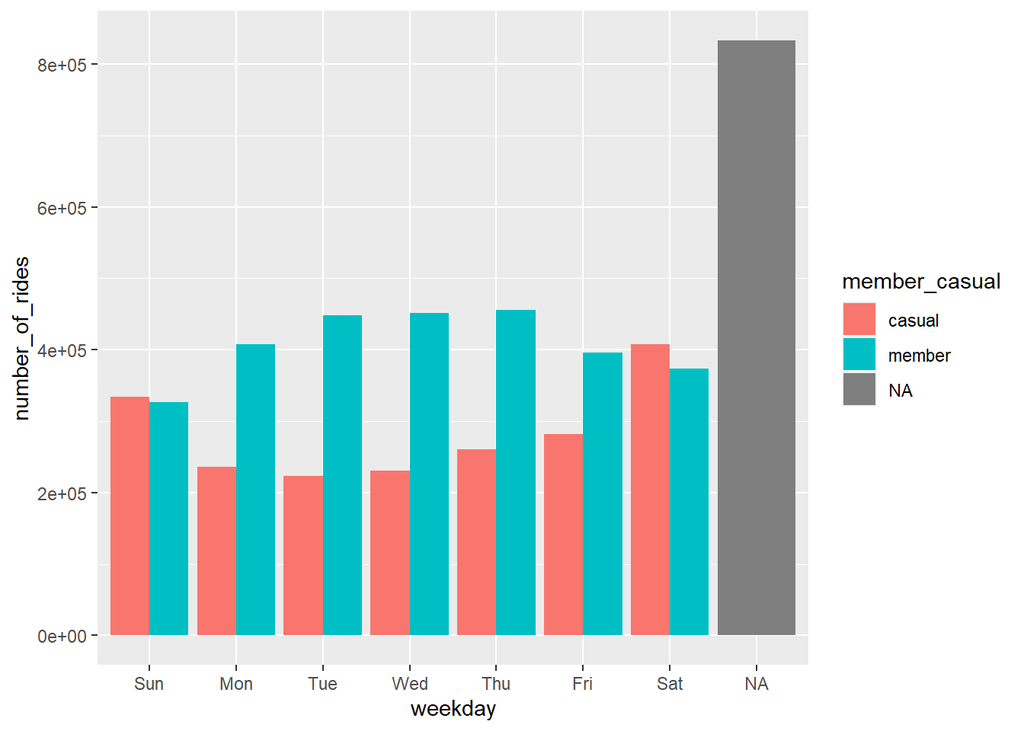

```r
# Let's visualize the number of rides by rider type
full_year_rides_v2 %>%
  mutate(weekday = wday(started_at, label = TRUE)) %>%
  group_by(member_casual, weekday) %>%
  summarise(number_of_rides = n()
            ,average_duration = mean(ride_length)) %>%
  arrange(member_casual, weekday)  %>%
  ggplot(aes(x = weekday, y = number_of_rides, fill = member_casual)) +
  geom_col(position = "dodge")
```

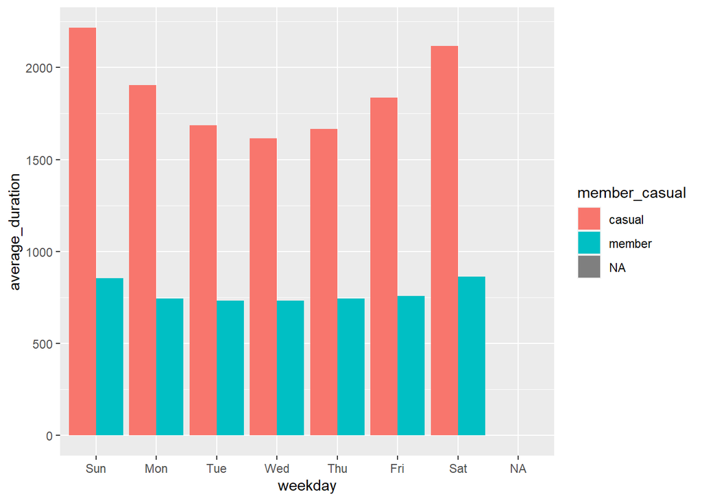

```r
# Let's create a visualization for average duration
full_year_rides_v2 %>%
  mutate(weekday = wday(started_at, label = TRUE)) %>%
  group_by(member_casual, weekday) %>%
  summarise(number_of_rides = n()
            ,average_duration = mean(ride_length)) %>%
  arrange(member_casual, weekday)  %>%
  ggplot(aes(x = weekday, y = average_duration, fill = member_casual)) +
  geom_col(position = "dodge")
```